# Interplay of Text, Reader And Context (InTRACt) in children’s digital reading comprehension: Preregistration

# Abstract

Children’s reading comprehension involves the interplay of three dimensions: the text (its lexical, syntactic, and discourse characteristics), the reader (developing reading fluency, built through accumulated reading experience), and the reading context (the digital medium and the child’s linguistic environment). Despite substantial laboratory-based progress in characterising each dimension in isolation, their joint influence under naturalistic, multilingual conditions is poorly understood. The present preregistration describes the InTRACt study, which addresses this gap by analysing large-scale behavioural logs from *Let’s Story*, an AI-powered storytelling feature of the *Applaydu* edutainment app deployed across 19 languages. Reading time per word is the outcome; because the platform records no cross-linguistically comparable comprehension measure, the confirmatory inferences concern reading behaviour and its predictors rather than comprehension itself. For each story, a broad range of computational text features will be extracted and reduced to principal components before model entry. Within-child reading experience — how much the child has read across prior sessions — is treated as a developing-fluency predictor, expected to speed reading as it accumulates. All confirmatory analyses use Bayesian multilevel models with random effects for child and language, so that text-feature effects are estimated across the 19 languages of the corpus. Two hypotheses are pre-registered: that syntactic and lexical complexity slow reading while discourse coherence accelerates it, and that children read progressively faster as they accumulate reading experience within the app.

# 1 Background

## 1.1 Text-Level Predictors of Reading Comprehension

A longstanding tradition in computational psycholinguistics explains reading comprehension in terms of measurable text and reader variables. This body of work identifies specific linguistic features, operating at the lexical, syntactic and discourse levels, that predict how readers engage with and understand text.

At the lexical level, word frequency is among the most reliable predictors of reading behaviour. High-frequency words are recognised faster and fixated for shorter durations than low-frequency words, a pattern replicated across dozens of eye-tracking studies and remarkably consistent across languages and orthographies: word length and frequency exert effects of strikingly similar magnitude across twelve typologically diverse alphabetic languages (Kuperman et al., 2024), evidencing the cross-linguistic regularity on which a multilingual analysis like the present one depends. That regularity of feature effects coexists, however, with large between-language differences in how quickly literacy is acquired and how fast text is read: foundation literacy develops markedly more slowly in deep orthographies such as English than in shallow ones (Seymour et al., 2003), grain-size accounts predict systematic cross-orthography differences in reading strategy (Ziegler & Goswami, 2005), and multilingual eye-tracking documents wide between-language variation in reading speed (Siegelman et al., 2022) — differences the present design absorbs through within-language standardisation and language-level random effects (see Analytic Plan). In children, lexical access is less automatised, so lexical properties such as frequency and semantic diversity exert strong and still-developing effects on word reading (Hsiao & Nation, 2018), and eye-movement studies of connected reading show that children’s fixation times are disproportionately lengthened by low-frequency and long words relative to adults’ (Joseph et al., 2013; Tiffin-Richards & Schroeder, 2015). Frequency norms derived from subtitle corpora (e.g., the Subtitle Lexical Frequencies [SUBTLEX] databases), including SUBTLEX-UK for British English (van Heuven et al., 2014), have become standard tools for operationalising this variable, offering estimates that closely approximate everyday language exposure (Brysbaert & New, 2009). More recently, resources such as the Children and Young People’s Books Lexicon (CYP-LEX) — derived from 1,200 books read by children and young people in the United Kingdom — offer a more ecologically valid frequency baseline for studies of developing readers, capturing the vocabulary children actually encounter in their reading environment (Korochkina et al., 2024). A related lexical property, word concreteness, also shapes comprehension: concrete, highly imageable words (e.g., *apple*, *river*) are processed more quickly than abstract words (e.g., *justice*, *theory*) (Magnabosco & Hauk, 2024). This concreteness advantage, classically attributed to dual-coding theory, in which concrete words activate both verbal and imagistic representations (Paivio, 1991), and in contemporary work to grounded and hybrid modal–amodal accounts (Bernabeu, 2022; Kaup et al., 2025), is expected to matter especially early in development: earlier-acquired word meanings are systematically more concrete, consistent with sensorimotor grounding of the early lexicon (Muraki et al., 2025). Consistent with this, Pickren et al. (2022) demonstrated that text characteristics including word emotionality and concreteness predict significant unique variance in reading performance among elementary school children, above and beyond traditional readability metrics. A third lexical variable, the diversity of vocabulary within a text — operationalised through indices such as the type/token ratio (TTR) or the Measure of Textual Lexical Diversity (MTLD) (McCarthy & Jarvis, 2010) — contributes to text difficulty. Because vocabulary knowledge is itself a strong determinant of children’s reading comprehension (Lervåg & Aukrust, 2010), the demands of lexically varied text are expected to fall most heavily on readers with weaker vocabularies, including many children.

At the syntactic level, sentence structure exerts its own demands on the reader. Measures such as mean dependency distance (the average linear distance between syntactically related words), the number of embedded clauses and subordination ratios capture aspects of structural complexity, and sensitivity to such structure is a distinct contributor to reading comprehension (Nielsen et al., 2025). Longer dependency distances, in particular, impose greater working memory demands, as readers must maintain information across intervening material before resolving a syntactic relationship (Gibson, 1998) — a load that weighs especially heavily on children, whose syntactic processing is still developing (Delage & Frauenfelder, 2019). Converging evidence comes from Marjokorpi & van Rijt (2025), who found that explicit grammatical understanding was a robust predictor of reading comprehension in secondary-school students even after controlling for socioeconomic background, writing ability, and other literacy-related factors — underscoring that sensitivity to syntactic structure continues to underlie comprehension development well into adolescence.

Beyond words and sentences, the coherence of a text, the degree to which successive ideas are logically and semantically connected, is central to comprehension. Computational measures of coherence, including latent semantic analysis (LSA)-based sentence-to-sentence similarity, co-reference overlap and connective density, index the ease with which readers can integrate information across a passage (Crossley et al., 2019). On construction–integration accounts, breaks in coherence oblige the reader to generate bridging inferences, a process that costs time and working memory (Kintsch, 1988); highly coherent texts accordingly support faster integration and better comprehension, particularly for readers with lower prior knowledge (McNamara et al., 1996) — the relevant case for child readers encountering newly generated stories. Complementing these deeper semantic relations are surface-level cohesion signals: explicit connectives such as *because*, *however* and *therefore* that mark the logical structure of a text. Automated tools such as Coh-Metrix (Graesser et al., 2014) now make it possible to compute many coherence and cohesion indices at once, enabling large-scale analyses of text difficulty that would be impractical to conduct by hand (Crossley, 2025).

These individual variables have also been combined into composite indices of text difficulty. Classical readability formulae (e.g., Flesch–Kincaid, Dale–Chall) aggregate surface features such as word length and sentence length into single scores, and although they are limited in linguistic sophistication, they remain widely used in educational and applied contexts (Crossley et al., 2023). More recent multi-dimensional frameworks integrate frequency, concreteness, syntactic complexity and coherence into richer characterisations of text difficulty, moving beyond simple heuristics toward discourse-level representations (Crossley et al., 2023; Crossley, 2025; Li et al., 2025).

Taken together, this body of research establishes that reading comprehension is jointly shaped by many text-level variables operating across multiple linguistic levels, alongside substantial reader differences in vocabulary and language skill (Duff & Brydon, 2020; Nation, 2019) — one facet of a broader reconceptualisation of reading comprehension as a multidimensional process shaped by reader, purpose and context (Goldman, 2024). These variables predict reading behaviour — including reading time, fixation patterns and comprehension accuracy — in both children and adults, though with developmental differences in magnitude and direction. The present study builds on this tradition by incorporating these established predictors as fixed effects in our analytic models (see Analytic Plan). We turn next to a more recent line of work that complements these feature-based approaches with neural language models.

## 1.2 Computational Modelling of Reading With Neural Language Models

While the text-level features reviewed above offer interpretable, theory-driven predictors of reading behaviour, a parallel line of research has begun to ask whether the representations learned by neural language models can capture the same reading phenomena — and potentially go beyond what hand-crafted features achieve. This approach treats the internal states of large language models (LLMs) as proxies for the representations that the human language system constructs during reading, and evaluates their fit to behavioural and neural data.

In adults, language models predict reading behaviour with considerable accuracy: their word-by-word predictions reproduce eye-movement patterns across different reading tasks (Hahn & Keller, 2023) and align closely with neural responses to sentences (Hosseini et al., 2024), indicating that core linguistic mechanisms — chiefly word predictability — are well captured by current models.

Extending this work to child readers presents both opportunities and challenges. Monaghan (2023) reviews how computational models originally developed for adult word reading have been adapted to simulate literacy acquisition in children, tracing the developing connections between orthography, phonology and semantics across languages. Empirical work has begun to complement these simulations with large-scale behavioural data: Sortkær et al. (2021), for instance, analysed logs from approximately 11,000 Danish schoolchildren using a reading app (BookBites) and found a moderate positive correlation (*r* ≈ 0.4) between app-derived reading speed and standardised reading test scores — indicating that computational metrics extracted from naturalistic digital reading can meaningfully index developing literacy.

In sum, neural language models complement the traditional text-feature approach: where hand-crafted variables capture well-understood sources of variation, model-derived measures may capture subtler distributional and contextual regularities (Seidenberg & MacDonald, 2018). However, for child readers, the evidence base is thinner, and many of the traditional text-level variables (frequency, coherence, syntactic complexity) may still be the most informative predictors. Our study is positioned at this intersection, using both established linguistic features and a model-derived index of word predictability (surprisal) to predict children’s reading behaviour in a large multilingual sample. Table 1 summarises the key studies from both traditions that inform our hypotheses.

Table 1: Representative computational-reading studies by age group

[output not shown]

## 1.3 Reading Experience and the Growth of Reading Fluency

The reader does not stay fixed across the period of observation: children grow more fluent as they read more. The cognitive mechanism is well established — under automaticity theory, practice renders word recognition increasingly automatic, so that it demands less attention and proceeds faster, freeing resources for comprehension (LaBerge & Samuels, 1974). On the complementary self-teaching account, each successful decoding of a novel word lays down orthographic representations that speed its subsequent recognition (Share, 1995), and the resulting gains in word-level efficiency free capacity for text-level processing (Perfetti, 2007) — a mechanism directly engaged by an app in which every story is newly generated. At the level of individual differences, the volume of reading a child accumulates is reliably associated with the growth of reading skill: a meta-analysis of print exposure from infancy to early adulthood found that how much children read predicts decoding fluency, comprehension and vocabulary, with the association strengthening across development (Mol & Bus, 2011). These relations are widely held to be reciprocal — more skilled readers read more, and more reading further builds skill — the “Matthew effect” by which early advantages compound over time (Stanovich, 1986).

The within-child direction of this relation is, however, not settled for younger readers. A longitudinal study following children from age 5 to 15 found reciprocal links between print exposure and reading skill throughout, but the effect of accumulated practice on later reading emerged only in adolescence, with skill driving amount more than the reverse during the early school years (van Bergen et al., 2021). Large-scale panel data also indicate that, among schoolchildren, the amount of time spent reading predicts subsequent growth in reading comprehension, and that the concurrent association weakens from the school years into adulthood (Locher & Pfost, 2020). Other longitudinal work documents substantial between-child variation in how quickly fluency develops (Khanolainen et al., 2024), and shorter-term evidence indicates that readers who read more text gain reading speed faster than those who read less (Schmidtke et al., 2024). Such effects are increasingly measurable from naturalistic behavioural logs: in primary-school children, app-logged reading time predicts reading fluency more strongly than parental self-report and retains predictive value when both are entered together (Brossette et al., 2026). This mixed but suggestive picture is what motivates testing, within the same children and at scale, whether reading time per word falls as a child accumulates reading experience across sessions (H2) — a question this naturalistic design is well placed to address, and one we frame as associational rather than developmental given the short observation window.

## 1.4 App-Based Data in Reading Research

Although digital reading is now widespread and much studied (Altamura et al., 2025; Furenes et al., 2021), and reading on screen carries a small but reliable comprehension cost relative to paper (Delgado et al., 2018) — so that findings from a screen-based corpus characterise digital reading specifically — few computational studies have used app-generated logs as a window into reading processes. The work that does exist falls broadly into two categories, which differ in their origins and scientific utility.

The first category comprises research and educational apps — platforms designed with learning objectives and, often, data collection in mind. Sortkær et al. (2021) exemplifies this approach: by analysing reading logs from BookBites, a classroom-deployed app, they demonstrated that passively recorded reading speed correlated meaningfully with standardised reading ability. Such studies establish the principle that app logs can reflect underlying cognitive processes, but they typically operate within controlled educational settings and with relatively constrained populations.

The second category, commercial ‘edutainment’ apps, is far less explored in the academic literature, despite its vastly larger user base. These apps combine entertainment with incidental learning goals, and their data are generated under naturalistic, unconstrained conditions. A case in point is *Let’s Story*, an artificial intelligence (AI)-powered digital storytelling feature embedded within *Applaydu* — an edutainment app developed by Gameloft and Ferrero International — which enables families to co-create storybooks using Microsoft’s generative AI tools across 19 languages (Ratner et al., 2025); the platform itself passively logs each session’s reading time (see Materials). Children select from a menu of story elements (plot, setting, character and theme), and the app generates a unique narrative that is then read aloud by an AI narrator in the family’s chosen language. To our knowledge, no previous study has yet analysed data from Applaydu or any comparable commercial edutainment platform at scale through the lens of computational psycholinguistics. The existing literature on reading apps instead consists primarily of reviews and small-scale experiments examining specific app features, and content analyses have repeatedly found commercial educational apps to vary widely in instructional quality (Chatzopoulos et al., 2023; Furlong et al., 2025) — a caveat that applies to the Applaydu platform examined here.

This gap between the commercial availability of reading-app data and its scientific use is notable. Table 2 summarises the small number of relevant studies, along with their sample contexts and key findings.

Table 2: Selected studies on app-based reading data

[output not shown]

The present project addresses this gap directly. By analysing large-scale multilingual behavioural logs from the *Let’s Story* feature of Applaydu, we aim to test whether the text-level variables identified in the laboratory-based literature — frequency, lexical diversity, syntactic complexity, coherence — predict children’s reading behaviour in the wild, across the 19 languages of the corpus.

These aims translate into two research questions that the confirmatory analyses address directly. The first (RQ1) concerns whether the lexical-distributional, syntactic-structural, and discourse-coherence properties of a story predict how long children spend reading each word. The second (RQ2) concerns whether children read progressively faster as they accumulate reading experience across successive sessions within the app. Each question maps onto one of the two directional hypotheses set out below, which the study design table summarises together with their statistical tests and the interpretation of possible outcomes (Table 4).

# 2 Methods

## 2.1 Participants

The study sample consists of data from the *Let’s Story* feature of *Applaydu*, a commercially deployed edutainment app developed by Gameloft and Ferrero International that offers a range of activities targeting different skills. *Let’s Story* is one such activity, enabling families to co-create AI-generated storybooks using Microsoft’s generative AI tools across 19 languages. In the first six months following its launch in late 2024, *Let’s Story* facilitated over 2.4 million story sessions and generated more than 40,000 English-language stories (Ratner et al., 2025). We will include all children (aged 7 years and older) who meet the inclusion criteria below [exact *N* to be determined after data extraction]. All data are anonymised and collected passively, with no additional experimental manipulation. Children will be included if (a) parental consent was registered in-app, (b) they were aged 7 years or older as reported at registration, and (c) they completed first-time readings of at least five distinct stories. Sessions will be excluded if any page’s reading time falls below 2 seconds or exceeds 5 minutes, or if a page’s implied rate exceeds 10 words per second — far above the roughly 80–170 words per minute typical of readers aged 7 and above (Hasbrouck & Tindal, 2006) — with these bounds indicating page-turning without reading or abandonment of the session; sessions are further excluded if accounts are identified as duplicates via device fingerprinting, or if sessions were flagged by the app as incomplete (e.g., due to an app crash). Two properties of the registration data bound these criteria: the age band has no upper bound, and the logs identify accounts rather than readers, so sessions on a shared family device may include parental co-reading or use by siblings; both constraints are treated as measurement limitations and screened diagnostically (see Measures).

## 2.3 Materials

The reading materials consist of short narrative passages (200–400 words each) drawn from the *Let’s Story* library within the *Applaydu* app. These stories vary in vocabulary, syntax and coherence, providing natural variation in the text-level features of interest. Because the stories are generated by a large language model, their language is not a random sample of children’s literature — LLM-generated children’s stories tend to exceed age-appropriate vocabulary levels (Valentini et al., 2023) — so the observed distribution of every text feature will be reported, allowing readers to judge the difficulty range actually sampled.

For each story, we will compute computational text features organised into four theoretically motivated families and extracted with tools that operate across the languages represented in the corpus. Morphosyntactic annotation — tokenisation, lemmatisation, part-of-speech tagging, and dependency parsing — will be produced with Stanza, a neural pipeline providing Universal Dependencies models for more than 60 languages (Qi et al., 2020), so that the same operational definitions apply in every language. *Lexical-distributional features* include lexical diversity (the Measure of Textual Lexical Diversity [MTLD], type/token ratio, and lexical density) and log-transformed word frequency drawn from language-specific subtitle- and corpus-based norms (e.g., the SUBTLEX family and comparable resources) (Brysbaert & New, 2009; van Heuven et al., 2014); for languages with validated norms we additionally include age of acquisition and concreteness or imageability ratings. Within this lexical-distributional family we also include, bridging the feature-based and neural approaches reviewed above, word-by-word surprisal — the negative log probability of each word given its preceding context — computed from an autoregressive language model (per-language Goldfish models; see Table 3) and averaged across the story; surprisal is among the most reliable computational predictors of reading time, which increases linearly with surprisal — that is, logarithmically with word probability (Shain et al., 2024; Smith & Levy, 2013) — as expected under expectation-based accounts of comprehension (Levy, 2008). Language-model surprisal predicts reading times across typologically diverse languages (Varda & Marelli, 2023), supporting its cross-linguistic use here, though direct evidence in child readers remains limited — a gap the present study helps to address. *Syntactic-structural features* include mean dependency distance, clause count per sentence, subordination ratio, mean sentence length, and noun-phrase complexity indices (determiners and dependents per NP), all computed from the Stanza dependency graphs. *Semantic and discourse-coherence features* are led by sentence-to-sentence cosine similarity computed from language-agnostic sentence embeddings (LaBSE), which represent sentences from 109 languages in a shared space (Feng et al., 2022), complemented where available by co-reference and argument overlap and by connective density (additive, causal, temporal, and adversative connectives) derived from language-specific connective inventories. *Affective and pragmatic features* include sentiment valence, emotional arousal, and cognitive or social word-category counts, computed from validated lexica in the languages for which they exist.

Two principles govern cross-linguistic feature construction. First, each feature is defined operationally on the output of a single multilingual pipeline — Stanza for morphosyntax and LaBSE for semantic similarity — so that, for instance, mean dependency distance denotes the same computation in Finnish as in Spanish. Second, lexicon-dependent features (frequency, age of acquisition, concreteness, sentiment) exist only for languages with validated norms; a feature that is unavailable or unreliable for a language is recorded as missing and removed during pre-screening if its missingness within that language exceeds the threshold set in the Analytic Plan. All features are standardised within language before dimension reduction, and a sensitivity analysis repeats the dimension reduction separately within each language (see Sensitivity Analyses) to confirm that the pooled cross-linguistic component structure adequately represents within-language variation. This feature set will be reduced to a smaller number of principal components prior to model fitting (see Analytic Plan).

### 2.3.1 Operationalisation of Variables Across Languages

Table 3 specifies how each variable is operationalised and the source used to compute it. The guiding principle is to hold the measure constant across languages wherever a single validated cross-language tool or resource exists, and to fall back on language-specific validated norms — or to treat the feature as missing — only where it does not.

Table 3: Operationalisation of each text-feature variable and the source used to compute it across languages. Language-general measures (lexical diversity, all syntactic indices, coherence, and surprisal) are computed identically in every language; lexicon-dependent measures use a cross-language resource as the primary source, supplemented by native validated norms where they exist.

[output not shown]

These resources cover the languages represented in the *Let’s Story* corpus (see Participants). The language-general measures — lexical diversity, all syntactic indices, sentence-to-sentence coherence, and surprisal — are computed identically in every language by the same tools and therefore constitute a single measure applied across languages. Among the lexicon-dependent measures, word frequency (`wordfreq`) and valence and arousal (the NRC VAD lexicon and its translations) are likewise available from one cross-language resource for nearly every language in the sample (Thai lacks `wordfreq` coverage and its frequency is treated as missing; see the Appendix), with native validated norms — the SUBTLEX frequency databases and language-specific affective norms — used for the five most frequent languages as a convergent-validity check. Age of acquisition, concreteness, and the LIWC word-category counts have validated coverage for only a subset of languages; where a norm is unavailable or unreliable for a language, the corresponding feature is recorded as missing and removed by the pre-screening rule (see Analytic Plan), and the per-language PCA sensitivity analysis confirms that such omissions do not distort the component structure. Where robust tokenisation or dependency parsing is unavailable for a language (for example, a language without reliable automatic word segmentation), the affected features are flagged and, if necessary, that language is excluded from the relevant analyses.

The *Let’s Story* feature of Applaydu records several behavioural variables for each reading session: reading time (in seconds) per page and per story, interaction events (clicks, page flips, hint usage), and session metadata (language, an age flag, date/time). The platform does not record whether read-aloud narration was enabled, nor a comprehension measure that is comparable across the languages in the corpus, nor the auxiliary child- and family-level measures collected by other *Applaydu* activities (for example, a vocabulary score, a self-reported difficulty rating, a joint-engagement measure from shared play, or caregiver age). Child age is available only as a single “7 and older” band, with no finer resolution, so it serves solely as an inclusion criterion and cannot enter the models as a predictor or moderator. The analysis therefore rests on reading time and the session metadata, with reading time per word as the sole outcome.

## 2.4 Procedure

Reading occurs under naturalistic, unconstrained conditions (“in the wild”). We will restrict the analysis to first-time readings of each story (excluding repeated readings) and require a minimum of 5 distinct stories per child. Data extraction will preserve the chronological order of sessions but exclude all personally identifying information. To reduce the influence of extreme outliers, reading time values will be winsorised at the 1st and 99th percentiles within each language group.

## 2.5 Measures

The outcome is reading time per word, computed as total story reading time divided by word count. Because the platform records no comprehension measure that is comparable across the languages of the corpus, reading time per word is the sole outcome and no secondary comprehension outcome is analysed.

The predictor variables fall into two categories. Text features comprise the four families of computational indices described in Materials; these will be reduced to principal component scores before entering any model (see Dimension Reduction via Principal Component Analysis). The reader feature is within-child reading experience, operationalised primarily as the lagged, log-transformed cumulative number of words the child has read in prior sessions (with session order, the sequence position, retained as a robustness coding).

The resulting dataset has a multilevel structure. At Level 1, observations correspond to individual story-reading instances (one child reading one story). At Level 2, observations are nested within children. At Level 3, children are nested within languages. Because the text features are standardised within language before dimension reduction, the resulting principal component (PC) scores are centred within language by construction: text-feature effects are estimated from within-language variation between stories, and between-language differences in average text difficulty are absorbed by the Language random effects. Reading experience (cumulative words read) will be centred within child (person-mean centred) and divided by its pooled within-child standard deviation, so that its effect is estimated purely within child, is separated from between-child differences in total app usage, and is expressed on the same per-standard-deviation scale as the component scores — the scale on which the region of practical equivalence is defined (see Analytic Plan).

Four properties of the data condition the inferences these measures can support. First, reading time per word indexes reading effort only to the extent that the child sets the pace and engages with the text; we therefore verify that recorded reading time covaries with text length as a precondition for analysis (see Outcome-Neutral Quality Checks and Positive Controls), since without that relationship recorded times could not be read as an index of engagement with the text. Relatedly, reading time per word indexes processing effort and developing fluency rather than comprehension itself: children’s reading rate relates reliably to overall reading competence (Fuchs et al., 2001; Sortkær et al., 2021), but reading speed is not a consistent within-reader predictor of comprehension (Wallot et al., 2014), so the confirmatory inferences concern reading behaviour, and comprehension-level claims lie outside their scope. Second, because the data are observational, neither the child’s language nor the amount the child has read is experimentally assigned, and accumulated reading experience is further confounded with selective retention, in that children who remain in the app read more. We therefore frame the within-child experience effect as associational rather than causal — estimating it within child and net of the text-feature components, and accompanying it with a completer-only sensitivity analysis (see Sensitivity Analyses) — and report the selection limitation explicitly (Kraemer et al., 2000). Third, stories can be read aloud by the app’s AI narrator, and the logs do not record whether narration was enabled, so for an unknown fraction of sessions per-word times may reflect the narrator’s pacing rather than the child’s. Because text-to-speech pacing is far less sensitive to a text’s processing difficulty than child-paced reading, undetected narration would attenuate the text-feature effects towards zero — rendering the H1 tests conservative rather than anticonservative — while also compressing the within-child variation on which H2 relies; a pre-specified diagnostic therefore screens for narration-paced sessions (see Outcome-Neutral Quality Checks), and a sensitivity analysis excludes them. Fourth, the logs identify accounts rather than readers: the age band is parent-reported at registration with no upper bound, and sessions on a shared family device may include parental co-reading or use by siblings. We therefore interpret effects at the level of account-holders registered in the 7-and-older band, treat reader identity as a source of outcome noise that the very large sample attenuates but does not remove, and screen the per-language distribution of per-word reading rates against published child reading-rate ranges (Hasbrouck & Tindal, 2006), reporting the proportion of sessions faster than plausible child-paced reading. These constraints define the causal scope of the confirmatory tests and are revisited when each hypothesis is interpreted.

Figure 1 provides a schematic overview of the study’s conceptual framework, relating the text features and within-child reading experience to the reading-time outcome and the two preregistered hypotheses.

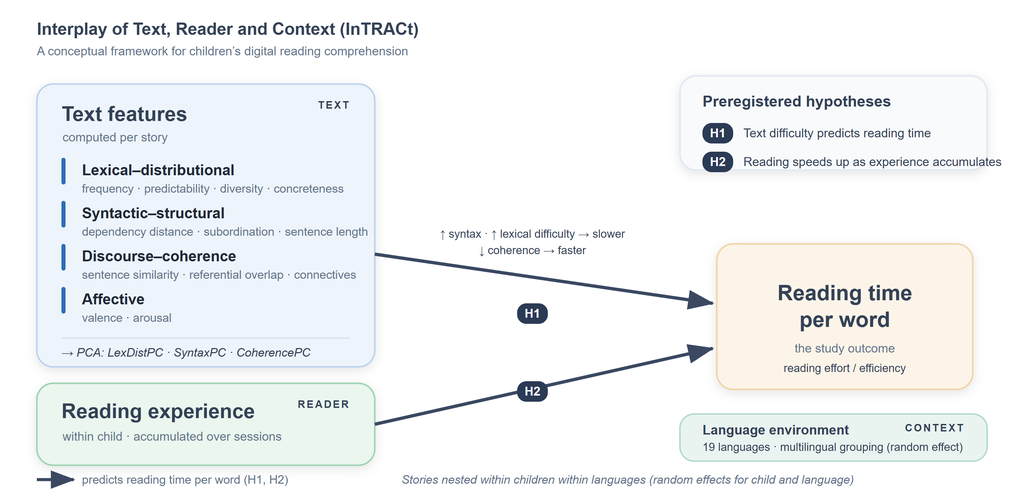

Figure 1: Conceptual framework of the InTRACt study. For each story, computational text features in four families — lexical-distributional (word frequency, predictability, lexical diversity, and concreteness), syntactic-structural (dependency distance, subordination, and sentence length), discourse-coherence (sentence-to-sentence similarity, referential overlap, and connectives), and affective (valence and arousal) — are reduced to principal components (LexDistPC, SyntaxPC, CoherencePC). These text-feature components predict the outcome of reading time per word (H1). Accumulated within-child reading experience — how much the child has read across prior sessions — is a second predictor of reading time (H2), expected to speed up reading as a child reads more. Whether reading experience additionally moderates the text-feature effects is examined as an exploratory question. Stories are nested within children within languages, with random effects for child and language, so that the analysis spans the 19 languages of the corpus.

## 2.6 Analytic Plan

All confirmatory analyses will use Bayesian hierarchical models fitted with the `brms` package (Bürkner, 2017), which implements full Bayesian inference via Hamiltonian Monte Carlo (No-U-Turn Sampler). We adopt this framework in preference to null-hypothesis significance testing because our scientific questions concern the *magnitude* and *direction* of effects rather than their mere existence, the expected sample size confers effectively unlimited frequentist power that renders *p*-value thresholds uninformative, and a single unified framework avoids the family-wise error inflation that arises from conditional multi-stage testing. Prior distributions are specified to be genuinely informative; their motivation and the prior placed on each parameter class are set out under Prior Specification below.

For each pre-registered hypothesis we will report, unconditionally and regardless of outcome, the posterior mean and 95% highest-density interval (HDI) for the relevant parameter; the posterior probability that the parameter falls in the predicted direction, P($\beta$ < 0) or P($\beta$ > 0) as specified per hypothesis; and the position of the 95% HDI relative to a region of practical equivalence (ROPE) (Kruschke, 2018) defined as $|\beta| < 0.05$ on the standardised scale — the threshold below which we consider an effect too small to be educationally meaningful. Each directional hypothesis is evaluated with the HDI+ROPE decision rule: a hypothesis is supported if the 95% HDI lies entirely outside the ROPE in the predicted direction; disconfirmed if the HDI lies entirely outside the ROPE in the opposite direction; the effect is declared practically equivalent to zero if the HDI lies entirely within the ROPE; and the result is otherwise inconclusive. Both confirmatory hypotheses are evaluated under this framework simultaneously and unconditionally, with no first-stage filter; the three text-feature sub-hypotheses (H1a–H1c; see Hypotheses) are estimated jointly in a single model and evaluated independently, with results reported per sub-hypothesis and no omnibus claim about H1 as a whole. Four chains of 4,000 iterations each (2,000 warm-up) will be run, with $\hat{R}$ < 1.01 and effective sample size > 1,000 per parameter as convergence diagnostics. Models will be fitted with the `cmdstanr` backend using within-chain parallelisation (`reduce_sum`), with the number of threads per chain fixed in the registered code; if a confirmatory model has not completed sampling within 14 days on the available high-performance-computing allocation, it will instead be fitted to a random subsample of children (100,000 children, drawn proportionally to language, with the sampling seed fixed in the registered code) — a contingency that is computational only, specified blind to any outcome, and leaves the inference criteria unchanged.

### 2.6.1 Prior Specification

We specify genuinely informative, regularising priors. This departs from the diffuse or default priors common in applied work; the default `brms` prior on population-level coefficients, for instance, is an improper flat prior that imposes no regularisation (Bürkner, 2017). This choice is motivated on two grounds. First, priors that concentrate mass on plausible parameter values regularise the posterior geometry and thereby improve Hamiltonian Monte Carlo sampling — reducing divergent transitions, raising effective sample sizes, and shortening warm-up and total sampling time — an instance of the principle that computational difficulties usually signal an under-constrained model rather than a purely numerical obstacle (Betancourt, 2017; Gelman et al., 2020). For a maximal random-effects structure over many-levelled and partly sparse Child and Language groupings, this regularisation is also what makes a complex model estimable within a feasible time frame, and more informative priors are known to speed convergence in exactly such hierarchical, reading-time models (McElreath, 2020; Schad et al., 2021). Second, although the very large sample means the likelihood will dominate the posterior for the main effects (Lemoine, 2019), the priors still do real work in the sparsely populated parts of the design — small language strata and the by-child random slopes — where they guard against implausibly large estimates.

Because the predictors are standardised and reading time is log-transformed, the fixed-effect coefficients are interpretable on a per-standard-deviation scale, on which reading-research effects are modest: word frequency and predictability enter reading time approximately logarithmically and with small per-unit slopes (Shain et al., 2024), and app-based reading-speed effects are moderate (*r* ≈ .39–.48) (Sortkær et al., 2021). We therefore place Normal(0, 0.2) priors on the population-level coefficients. Normal rather than Student’s *t* priors are used for these coefficients because their log-concave tails additionally aid sampling (Gelman et al., 2020). Because both hypotheses are evaluated confirmatorily and unconditionally, every prior is centred at zero and symmetric: it regularises through its scale alone and does not encode the predicted direction, so the data remain free to disconfirm each hypothesis (Schad et al., 2021). Group-level standard deviations (for Child, Language, and the random slopes) receive half-Normal(0, 1) priors, as does the residual standard deviation; the random-effect correlation matrices receive LKJ($\eta$ = 2) priors, which place the mode at the identity matrix and gently discourage the near-perfect random-slope correlations that drive divergences in maximal models (Bürkner, 2017; Lewandowski et al., 2009).

All priors will be examined with prior predictive simulations before any model is fitted to the data, and their influence will be quantified in a pre-registered prior-sensitivity analysis that compares them against the weakly informative alternatives (see Sensitivity Analyses), in line with recommended Bayesian-workflow practice (Schad et al., 2021; van de Schoot et al., 2021).

### 2.6.2 Sampling Plan and Inferential Sensitivity

Because the study analyses pre-existing observational data, the sampling plan is defined by the inclusion and exclusion criteria (see Participants) rather than by recruitment, and the analytic sample — first-time story readings nested within children, who are nested within languages — is expected to be very large: in its first six months the platform recorded over 2.4 million story sessions and more than 40,000 generated English-language stories (Ratner et al., 2025). The exact analysable *N* is fixed by the pre-registered filters and is unknown until extraction. At this scale the binding constraint on inference is the precision of estimation and the *practical* magnitude of effects, rather than statistical power: even negligible effects attain conventional significance when *N* is in the millions (Gelman & Carlin, 2014). We therefore replace a conventional power analysis with a precision-based Bayesian design analysis organised around the region of practical equivalence (ROPE) and the highest-density-interval decision rule (Kruschke, 2018).

### 2.6.3 Outcome-Neutral Quality Checks and Positive Controls

To confirm that the data and the analysis pipeline can detect known effects before the focal hypotheses are evaluated, we pre-specify the following outcome-neutral checks. First, as a validity check on the timing measure, total story reading time must increase with story word count; the check passes if, within each of the five largest languages, the posterior slope of log total reading time on log word count is positive with posterior probability of at least .95. Its absence would indicate that recorded times do not reflect engagement with the text. Second, as a positive control on the feature pipeline, we will fit a minimal ancillary model predicting log reading time per word from story-mean Zipf word frequency alone (with random intercepts for Child and Language), separate from the PCA-based confirmatory models; word frequency is the most robust and cross-linguistically replicable lexical predictor of reading time (Kuperman et al., 2024; van Heuven et al., 2014), and the control passes if the posterior probability of a negative frequency slope exceeds .95. Because word frequency also loads on the lexical-distributional component, this control is not independent of H1’s lexical sub-hypothesis (H1b): it is therefore treated as a pipeline check on which the syntactic (H1a) and coherence (H1c) tests are conditioned, while the lexical test (H1b) is interpreted jointly with it. Third, the per-language distribution of reading time per word will be screened for floor and ceiling effects and for adequate variance; an outcome lying at floor or ceiling for more than 90% of observations within a language will not be modelled in that language. Fourth, because narration status is unrecorded (see Measures), we will screen for narration-paced sessions: text-to-speech pacing is nearly constant per word, so for each language we will inspect the distribution of per-word times for a low-variance mode at a language-consistent rate; sessions falling within such a mode will be flagged, the flagged proportion reported, and the confirmatory models re-fitted without them as a pre-registered sensitivity analysis (see Sensitivity Analyses). These checks are evaluated before the confirmatory models; where a check fails, the dependent confirmatory test is reported as uninterpretable rather than as evidence for or against the corresponding hypothesis.

### 2.6.4 Dimension Reduction via Principal Component Analysis

Before fitting any mixed-effects model, we will reduce the full set of text-level features to a smaller number of stable, interpretable components using PCA, following the approach of Crossley (2025). PCA is chosen over exploratory factor analysis because the goal is dimension reduction of observed stimulus properties rather than estimation of unobserved latent causes: there is no theoretical basis for claiming that a latent factor *causes* MTLD, dependency distance and connective density to co-vary, and treating them as reflective indicators of a latent construct would misrepresent the nature of computational linguistic indices (Crossley, 2025).

All retained variables will be $z$-scored within language before PCA, removing between-language scale differences while preserving within-language variation. The primary analysis pools all language-standardised variables into a single PCA conducted in R using the `psych` package (Revelle, 2023), after verifying the Kaiser–Meyer–Olkin (KMO) measure of sampling adequacy (individual KMO > .50; overall KMO > .60); variables with individual KMO below .50 are removed iteratively, lowest first, with the KMO recomputed at each step. Bartlett’s test of sphericity is reported for completeness only, since at this sample size it rejects trivially and carries no decision weight. We use oblique rotation (promax, $\kappa$ = 4) rather than varimax, because linguistic features are naturally correlated and an orthogonality assumption is theoretically unjustified (Biber, 1988; Crossley, 2025). Components will be retained based on three jointly applied criteria: parallel analysis (Horn, 1965), which retains components whose eigenvalues exceed the 95th percentile from 10,000 matched random data structures; scree-plot inspection; and interpretability, with a component accepted only if the pattern matrix admits a coherent reading-theoretic interpretation. Variables with absolute pattern loadings below .30 will not be attributed to any component. Component scores for each retained component will then be computed per story by the regression method (`psych::principal`) and will serve as text-level predictors in the confirmatory models below. The full pattern matrix (all loadings ≥ .15), component-score intercorrelations, proportion of variance per component, and per-variable KMO values will be reported in a supplementary table, with each component named based on its highest-loading variables and theoretical interpretation.

### 2.6.5 Confirmatory Models

The confirmatory model predicts log-transformed reading time per word — log transformation normalises the positively skewed distribution, with posterior predictive fit verified via `pp_check` plots — from the retained text-feature PC scores and within-child reading experience (lagged log cumulative words read, person-mean-centred and scaled; see Measures). The random-effects structure follows a maximal justified specification (Barr et al., 2013), with random intercepts for Child and Language, random slopes for the hypothesis-bearing PC components and for reading experience within Child, and random slopes for the hypothesis-bearing components within Language (e.g., `(1 + LexDistPC + SyntaxPC + CoherencePC + Experience | Child) + (1 + LexDistPC + SyntaxPC + CoherencePC | Language)`), so that the fixed text-feature effects are estimated as averages over languages rather than dominated by the largest language groups; the posterior standard deviations of the by-language slopes are reported as the pre-registered index of cross-linguistic consistency. Because stories are generated uniquely for each family, most stories are expected to be read by a single child, and text-feature effects are identified predominantly from variation across each child’s own stories; at extraction we will report the proportion of observations contributed by stories read by more than one child, and if it exceeds 5% a crossed random intercept for Story will be added to account for shared story-level variability (Judd et al., 2012). The confirmatory ROPE/HDI decisions are taken from the winsorised, untrimmed model; as a sensitivity analysis, observations with standardised residuals exceeding ±3 *SD* based on posterior predictive draws will be removed once, without iteration, and the model re-fitted (see Sensitivity Analyses).

### 2.6.6 Convergence and Multicollinearity

A random intercept for *Language* will be included in all models to account for between-language variability and enable partial pooling. Non-convergence is defined as any $\hat{R}$ ≥ 1.01, bulk or tail effective sample size below 1,000 on a reported parameter, or more than 0.1% divergent transitions. We will first increase `adapt_delta` to 0.95 and then 0.99 (with `max_treedepth` = 12); only if diagnostics still fail will we simplify the structure, removing the random slope with the smallest posterior standard deviation — by-child slopes before by-language slopes, and never a term required to identify a hypothesis — iterating until convergence and reporting every step. Residual multicollinearity among the retained PC scores will be assessed using variance inflation factors (VIF) on the fixed-effects design matrix after the dimension-reduction step. No hypothesis-bearing component will be removed on collinearity grounds: if any VIF exceeds 5, any retained component not named in a hypothesis is removed first, and if collinearity among SyntaxPC, LexDistPC and CoherencePC alone drives a VIF above 10, the affected sub-hypothesis is declared untestable on collinearity grounds and the joint posterior of the correlated coefficients is reported instead.

### 2.6.7 Model Comparison

We will compare the full model against reduced models that drop the text-feature components and the reading-experience term in turn, using K-fold cross-validation grouped by child (K = 10; `brms::kfold`), which targets the relevant generalisation — prediction for new children — and avoids storing the pointwise log-likelihood matrix that exact leave-one-out cross-validation would require at this scale (Vehtari et al., 2017). We report the expected log predictive density (ELPD) difference and its standard error; a model is preferred only if the ELPD difference exceeds four and is at least twice its standard error, with smaller differences reported as predictively indistinguishable. Cross-validation is preferred over likelihood-ratio tests because it requires no asymptotic approximations and is well-calibrated within the Bayesian framework adopted here.

### 2.6.8 Minimum Effect Size and ROPE Calibration

ROPE bounds are informed by standardised effect sizes from the closest available prior studies: Sortkær et al. (2021) reported $r$ ≈ .39–.48 for reading-speed effects, and syntactic complexity effects on children’s reading times in eye-tracking studies are typically in the range $d$ = 0.2–0.5. A standardised $\beta$ of 0.05 is therefore conservatively below the range of effects the existing literature considers educationally meaningful. The same ±0.05 bound applies to the H2 experience slope, which is scaled to the per-standard-deviation metric before model entry (see Measures). Sensitivity analyses varying the ROPE bound to ±0.03 and ±0.10 will assess the robustness of practical-equivalence conclusions.

### 2.6.9 Sensitivity Analyses

Ten pre-registered sensitivity analyses will assess the robustness of the main findings. First, the primary models will be re-fitted without any outlier exclusion criteria, to establish whether winsorisation drives any substantive conclusion. Second, complementing this from the other side, observations with posterior-predictive standardised residuals beyond ±3 *SD* will be removed in a single pass and the models re-fitted (see Confirmatory Models). Third, the models will be restricted to the five largest language groups, to evaluate cross-linguistic generalisability independently of less-represented languages. Fourth, the ROPE bounds will be varied to ±0.03 and ±0.10 as described above. Fifth, the confirmatory models will be re-estimated using sparse PCA scores — obtained via the R package `sparsepca`, with sparsity regularisation selected by cross-validation — to assess whether structurally simpler components with fewer non-zero loadings alter the substantive pattern of results. Sixth, language-specific PCAs will replace the pooled solution, with one PCA fitted per language (attempted only for languages with at least 300 stories), to test whether the cross-lingual feature space adequately represents within-language variation; congruence between each per-language solution and the pooled solution will be quantified with Tucker’s congruence coefficient, taking $\varphi$ ≥ .85 as fair similarity and $\varphi$ ≥ .95 as equivalence (Lorenzo-Seva & Berge, 2006), and the confirmatory models will be re-fitted excluding any language whose hypothesis-bearing components fall below .85. Seventh, the sample will be restricted to children who completed a higher minimum number of sessions (a completer-only subsample), to assess whether selective retention biases the within-child reading-experience effect (H2). Eighth, a prior-sensitivity analysis will re-fit the confirmatory models under the previously specified weakly informative priors (Student’s *t*(3, 0, 2.5) on the fixed effects) and — because at this sample size the group-level priors do the real regularising work — under half-Normal(0, 0.5) and Exponential(1) alternatives for all group-level and residual standard deviations and LKJ($\eta$ = 1) and LKJ($\eta$ = 4) alternatives for the correlation matrices, to confirm that the substantive conclusions are driven by the data rather than by the priors (van de Schoot et al., 2021). Ninth, to separate within-child experience from platform-level drift (app updates, changes to the story generator) and from seasonal variation, the H2 model will be re-fitted with a spline of calendar week since feature launch and with days-since-first-session (person-mean-centred) as an additional within-child covariate; H2 is interpreted as robust only if the experience effect persists. Tenth, the confirmatory models will be re-fitted excluding the sessions flagged by the narration-pacing screen (see Outcome-Neutral Quality Checks and Positive Controls).

### 2.6.10 Supplementary Frequentist Models

To facilitate comparison with prior literature and to assist readers unfamiliar with Bayesian inference, fixed-effect point estimates, standard errors, and confidence intervals from a maximum-likelihood linear mixed model (LMM; fitted with `lme4`/`lmerTest`, identical random-effects structure) will be reported in a supplementary table. These results are descriptive only and carry no confirmatory weight; all hypothesis evaluation is conducted solely via the Bayesian framework described above.

# 3 Hypotheses

Our hypotheses are directional and each maps onto a specific fixed-effect term in the confirmatory model described above. Following the PCA procedure described in the Analytic Plan (see Dimension Reduction via Principal Component Analysis), hypotheses about text-level features are stated in terms of the PC component families expected to carry the relevant variance. The syntactic-structural component is referred to as SyntaxPC; the semantic/coherence component as CoherencePC; and the lexical-distributional component as LexDistPC. Because exact component names will be assigned post-hoc from the pattern matrix, each directional prediction is conditional on a component with the expected feature profile emerging from the PCA. To remove analyst discretion from that step, component matching is algorithmic, with marker variables fixed in advance: SyntaxPC — mean dependency distance, subordination ratio, and clause count per sentence; CoherencePC — sentence-to-sentence embedding similarity, argument overlap, and connective density; LexDistPC — Zipf word frequency (reverse-scored), surprisal, and MTLD. A retained component is designated as a hypothesised component if and only if it is the retained component with the highest mean absolute pattern loading on that family’s markers and at least two of the three markers load on it at ≥ .30 with a consistent sign. If no retained component satisfies this rule for a family, the corresponding sub-hypothesis will be reported as untestable.

First, we predict that text-level features predict reading time: stories scoring higher on syntactic and lexical difficulty — with longer dependency distances, less frequent words, higher lexical diversity and lower coherence — should be associated with longer reading times per word. We expect (H1a) a main effect of SyntaxPC in the direction of longer reading times; (H1b) a main effect of LexDistPC in the direction of longer reading times; and (H1c) a main effect of CoherencePC in the direction of shorter reading times. The three sub-hypotheses are estimated jointly in a single model and evaluated independently: support for any subset is reported as such, and no omnibus claim is made about H1 as a whole.

Second, we predict that children read progressively faster as they accumulate reading experience within the app. Reading practice builds fluency and lowers reading time over time, as indicated by app-based reading logs and longitudinal studies of reading experience (Schmidtke et al., 2024; Sortkær et al., 2021), so reading time per word should decrease as a child reads more. We operationalise within-child experience primarily as the cumulative number of words the child has read in prior sessions, lagged so the current story is excluded, log-transformed to capture the diminishing-returns shape characteristic of practice curves (Logan, 1988), and centred within child (person-mean), so that the effect is estimated purely within child and is not confounded with between-child differences in total app usage (Kraemer et al., 2000); the simpler session-order count (sequence position) is retained as a robustness coding. We use cumulative words rather than cumulative reading time, because the latter is constructed from the dependent variable. We expect a negative main effect of accumulated reading on reading time, with a by-child random slope capturing individual differences in practice rate. Because retention in the app is self-selected, this effect is associational — estimated within the children who remain and net of the text-feature components already in the model — and is accompanied by a completer-only sensitivity analysis (see Sensitivity Analyses).

Each hypothesis will be evaluated through the corresponding mixed-model term using the Bayesian inference criteria described in the Analytic Plan (posterior mean, 95% HDI, directional posterior probability, and ROPE analysis). Both hypotheses are evaluated under the same inferential framework, applied unconditionally and simultaneously.

## 3.1 Study Design Table

Table 4: Study design table linking research questions, hypotheses, statistical tests, and the interpretation of possible outcomes. All confirmatory tests use the Bayesian multilevel models and the ROPE/HDI decision rule set out in the Analytic Plan; sampling adequacy for each test is established by the design analysis (see Sampling Plan and Inferential Sensitivity), and every test is conditional on the outcome-neutral quality checks.

[output not shown]

## 3.2 Exploratory Analyses

Beyond the confirmatory tests above, we plan several analyses that are explicitly designated as exploratory and will be reported separately.

We will examine whether the magnitude of text-feature effects on children’s reading varies systematically across the 19 languages represented in the *Let’s Story* dataset. This could be addressed through language-stratified models or through meta-regression with typological features (e.g., orthographic depth) as moderators — an approach that may reveal whether the relationships between, say, syntactic complexity and reading time are consistent across typologically diverse languages or are modulated by language-specific properties.

We will also explore whether text complexity features show non-linear (quadratic) relationships with reading time, which would suggest diminishing or accelerating effects at extreme levels of complexity.

Two further exploratory analyses build on the confirmatory within-child experience effect (H2). First, although the reviewed evidence that reading experience attenuates sensitivity to text difficulty concerns between-child skill differences rather than within-child change over a short window, we will explore whether accumulated experience moderates the text-feature effects — most plausibly attenuating the lexical-distributional cost, in line with the smaller lexical and word-length effects shown by more fluent and experienced readers (Lubineau et al., 2024) — while remaining agnostic about the syntactic and coherence components, for which the reviewed corpus is silent. Second, because practice curves are typically non-linear, we will compare the primary log-cumulative-words parameterisation against linear and by-child smooth (generalised additive) alternatives, and against the simpler session-order coding (Baayen et al., 2021). Throughout, accumulated reading is treated cautiously: it is confounded with selective retention and with drift in the difficulty of the stories served, so we verify that the confirmatory text-feature effects are unchanged when the experience term and its by-child slope are included, alongside the completer-only check reported under Sensitivity Analyses.

Two further exploratory checks probe the measurement basis of the confirmatory analyses. As an engagement check on H2, we will test whether per-session interaction density (page flips, clicks, and hint usage per page) declines with accumulated experience in parallel with reading time; a decline in reading time without a parallel decline in engagement is consistent with growing fluency, whereas parallel declines would qualify that interpretation towards disengagement or skimming. As a robustness check on the outcome’s level of aggregation, the primary model will also be re-fitted to page-level per-word reading times, which preserve within-story variation that the story-level aggregate removes.

All exploratory results will be clearly labelled as such in the manuscript, and we will not draw confirmatory conclusions from these analyses.

# Declarations

# Appendix: Per-Language Norm Sources

For the lexicon-dependent measures (frequency, age of acquisition, concreteness/imageability, valence/arousal, and the LIWC word-category counts), the validated native norms listed in Table 5 will be used wherever they exist. Every other language–measure combination defaults to the cross-language resource specified in Table 3 — `wordfreq` for frequency (Speer, 2022), the NRC VAD lexicon for valence and arousal (Mohammad, 2018), and the 25-language set of Łuniewska et al. (2016) for age of acquisition — or, where no validated norm is available, is recorded as missing and removed by the pre-screening rule (see Analytic Plan). Native frequency norms are additionally used to validate the `wordfreq` estimates. The language-general measures (lexical diversity, all syntactic indices, coherence, and surprisal) are computed identically across languages and are not repeated here.

Table 5: Validated native norm sources by language for the lexicon-dependent measures. Entries not listed use the cross-language defaults described in the text (`wordfreq` for frequency, the NRC VAD lexicon for valence and arousal, and the Łuniewska et al. (2016) set for age of acquisition) or are treated as missing under the pre-screening rule.

[output not shown]

The exact set of generation languages, and hence the rows of this appendix, will be fixed from the platform metadata at data extraction (see Participants).

## 4 References

Alonso, M. Á., Fernández, Á., & Díez, E. (2015). Subjective age-of-acquisition norms for 7,039 Spanish words. *Behavior Research Methods*, *47*(1), 268–274. https://doi.org/10.3758/s13428-014-0454-2

Altamura, L., Vargas, C., Naumann, J., & Salmerón, L. (2025). How digital reading habits shape reading motivation and comprehension over time: Longitudinal associations in primary school. *Developmental Psychology*. https://doi.org/10.1037/dev0002094

Baayen, R. H., Fasiolo, M., Wood, S., & Chuang, Y.-Y. (2021). *A note on the modeling of the effects of experimental time in psycholinguistic experiments*. https://doi.org/10.48550/arXiv.2105.13786

Barr, D. J., Levy, R., Scheepers, C., & Tily, H. J. (2013). Random effects structure for confirmatory hypothesis testing: Keep it maximal. *Journal of Memory and Language*, *68*(3), 255–278. https://doi.org/10.1016/j.jml.2012.11.001

Bernabeu, P. (2022). *Language and sensorimotor simulation in conceptual processing: Multilevel analysis and statistical power* [PhD thesis, Lancaster University]. https://doi.org/10.17635/LANCASTER/THESIS/1795

Betancourt, M. (2017). *A conceptual introduction to Hamiltonian Monte Carlo*. https://doi.org/10.48550/arXiv.1701.02434

Biber, D. (1988). *Variation across speech and writing* (1st ed.). Cambridge University Press. https://doi.org/10.1017/CBO9780511621024

Booton, S. A., Hodgkiss, A., & Murphy, V. A. (2023). The impact of mobile application features on children’s language and literacy learning: A systematic review. *Computer Assisted Language Learning*, *36*(3), 400–429. https://doi.org/10.1080/09588221.2021.1930057

Boyd, R. L., Ashokkumar, A., Seraj, S., & Pennebaker, J. W. (2022). *The development and psychometric properties of LIWC-22*. University of Texas at Austin. https://www.liwc.app/static/documents/LIWC-22%20Manual%20-%20Development%20and%20Psychometrics.pdf

Brossette, B., Persia-Leibnitz, L., Chalbos, M.-J., Prugnières, C., & Ducrot, S. (2026). Measuring reading time: Comparing logged and self-reported data in relation to reading skills. *PLOS ONE*, *21*(4), e0344853. https://doi.org/10.1371/journal.pone.0344853

Brysbaert, M., Buchmeier, M., Conrad, M., Jacobs, A. M., Bölte, J., & Böhl, A. (2011). The word frequency effect: A review of recent developments and implications for the choice of frequency estimates in German (SUBTLEX-DE). *Experimental Psychology*, *58*(5), 412–424. https://doi.org/10.1027/1618-3169/a000123

Brysbaert, M., & New, B. (2009). Moving beyond kučera and francis: A critical evaluation of current word frequency norms and the introduction of a new and improved word frequency measure for american english. *Behavior Research Methods*, *41*(4), 977–990. https://doi.org/10.3758/BRM.41.4.977

Brysbaert, M., Stevens, M., De Deyne, S., Voorspoels, W., & Storms, G. (2014). Norms of age of acquisition and concreteness for 30,000 Dutch words. *Acta Psychologica*, *150*, 80–84. https://doi.org/10.1016/j.actpsy.2014.04.010

Brysbaert, M., Warriner, A. B., & Kuperman, V. (2014). Concreteness ratings for 40 thousand generally known English word lemmas. *Behavior Research Methods*, *46*(3), 904–911. https://doi.org/10.3758/s13428-013-0403-5

Bürkner, P.-C. (2017). brms: An R package for Bayesian multilevel models using Stan. *Journal of Statistical Software*, *80*, 1–28. https://doi.org/10.18637/jss.v080.i01

Cai, Q., & Brysbaert, M. (2010). SUBTLEX-CH: Chinese word and character frequencies based on film subtitles. *PLOS ONE*, *5*(6), e10729. https://doi.org/10.1371/journal.pone.0010729

Chang, T. A., Arnett, C., Tu, Z., & Bergen, B. K. (2024). *Goldfish: Monolingual language models for 350 languages*. https://doi.org/10.48550/arXiv.2408.10441

Chatzopoulos, A., Karaflis, A., Kalogiannakis, M., Tzerachoglou, A., Cheirchanteri, G., Sfyroera, E., & Sklavounou, E.-O. (2023). Evaluation of Google Play educational apps for early childhood education. *Advances in Mobile Learning Educational Research*, *3*(2), 770–778. https://doi.org/10.25082/AMLER.2023.02.004

Chuang, C., & Jamiat, N. (2023). A systematic review on the effectiveness of children’s interactive reading applications for promoting their emergent literacy in the multimedia context. *Contemporary Educational Technology*, *15*(2), ep412. https://doi.org/10.30935/cedtech/12941

Crepaldi, D., Amenta, S., Mandera, P., Keuleers, E., & Brysbaert, M. (2015). SUBTLEX-IT: Subtitle-based word frequency estimates for Italian. *Proceedings of the Annual Meeting of the Italian Association for Experimental Psychology (AIP)*.

Crossley, S. A. (2025). Developing linguistic constructs of text readability using natural language processing. *Scientific Studies of Reading*, *29*(2), 138–160. https://doi.org/10.1080/10888438.2024.2422365

Crossley, S. A., Kyle, K., & Dascalu, M. (2019). The Tool for the Automatic Analysis of Cohesion 2.0: Integrating semantic similarity and text overlap. *Behavior Research Methods*, *51*(1), 14–27. https://doi.org/10.3758/s13428-018-1142-4

Crossley, S. A., Skalicky, S., Berger, C., & Heidari, A. (2023). Assessing readability formulas in the wild. In M. Dascalu, P. Marti, & F. Pozzi (Eds.), *Polyphonic Construction of Smart Learning Ecosystems* (pp. 91–101). Springer Nature. https://doi.org/10.1007/978-981-19-5240-1_6

Delage, H., & Frauenfelder, U. H. (2019). Syntax and working memory in typically-developing children: Focus on syntactic complexity. *Language, Interaction and Acquisition*, *10*(2), 141–176. https://doi.org/10.1075/lia.18013.del

Delgado, P., Vargas, C., Ackerman, R., & Salmerón, L. (2018). Don’t throw away your printed books: A meta-analysis on the effects of reading media on reading comprehension. *Educational Research Review*, *25*, 23–38. https://doi.org/10.1016/j.edurev.2018.09.003

Della Rosa, P. A., Catricalà, E., Vigliocco, G., & Cappa, S. F. (2010). Beyond the abstract-concrete dichotomy: Mode of acquisition, concreteness, imageability, familiarity, age of acquisition, context availability, and abstractness norms for a set of 417 Italian words. *Behavior Research Methods*, *42*(4), 1042–1048. https://doi.org/10.3758/BRM.42.4.1042

Desrochers, A., & Thompson, G. L. (2009). Subjective frequency and imageability ratings for 3,600 French nouns. *Behavior Research Methods*, *41*(2), 546–557. https://doi.org/10.3758/BRM.41.2.546

Duchon, A., Perea, M., Sebastián-Gallés, N., Martí, A., & Carreiras, M. (2013). EsPal: One-stop shopping for Spanish word properties. *Behavior Research Methods*, *45*(4), 1246–1258. https://doi.org/10.3758/s13428-013-0326-1

Duff, D., & Brydon, M. (2020). Estimates of individual differences in vocabulary size in English: How many words are needed to “close the vocabulary gap”? *Journal of Research in Reading*, *43*(4), 454–481. https://doi.org/10.1111/1467-9817.12322

Feng, F., Yang, Y., Cer, D., Arivazhagan, N., & Wang, W. (2022). Language-agnostic BERT sentence embedding. *Proceedings of the 60th Annual Meeting of the Association for Computational Linguistics (Volume 1: Long Papers)*, 878–891. https://doi.org/10.18653/v1/2022.acl-long.62

Ferrand, L., Bonin, P., Méot, A., Augustinova, M., New, B., Pallier, C., & Brysbaert, M. (2008). Age-of-acquisition and subjective frequency estimates for all generally known monosyllabic French words and their relation with other psycholinguistic variables. *Behavior Research Methods*, *40*(4), 1049–1054. https://doi.org/10.3758/BRM.40.4.1049

Fuchs, L. S., Fuchs, D., Hosp, M. K., & Jenkins, J. R. (2001). Oral reading fluency as an indicator of reading competence: A theoretical, empirical, and historical analysis. *Scientific Studies of Reading*, *5*(3), 239–256. https://doi.org/10.1207/s1532799xssr0503_3

Furenes, M. I., Kucirkova, N., & Bus, A. G. (2021). A comparison of children’s reading on paper versus screen: A meta-analysis. *Review of Educational Research*, *91*(4), 483–517. https://doi.org/10.3102/0034654321998074

Furlong, L., Serry, T., Erickson, S., Lefort, M., Gath, M., & Morris, M. (2025). Finding the needle in the haystack: A quality appraisal of mobile applications for foundational literacy skills. *Early Childhood Education Journal*. https://doi.org/10.1007/s10643-025-02066-8

Gelman, A., & Carlin, J. (2014). Beyond power calculations: Assessing Type S (sign) and Type M (magnitude) errors. *Perspectives on Psychological Science*, *9*(6), 641–651. https://doi.org/10.1177/1745691614551642

Gelman, A., Vehtari, A., Simpson, D., Carpenter, B., Margossian, C. C., Yao, Y., Kennedy, L., Gabry, J., Bürkner, P.-C., & Modrák, M. (2020). *Bayesian workflow*. https://doi.org/10.48550/arXiv.2011.01808

Gibson, E. (1998). Linguistic complexity: Locality of syntactic dependencies. *Cognition*, *68*(1), 1–76. https://doi.org/10.1016/S0010-0277(98)00034-1

Goldman, S. R. (2024). Reading is complex: Implications for research and practice. *Educational Psychologist*, *59*(4), 315–325. https://doi.org/10.1080/00461520.2024.2418062

Graesser, A. C., McNamara, D. S., Cai, Z., Conley, M., Li, H., & Pennebaker, J. (2014). Coh-metrix measures text characteristics at multiple levels of language and discourse. *The Elementary School Journal*, *115*(2), 210–229. https://doi.org/10.1086/678293

Hahn, M., & Keller, F. (2023). Modeling task effects in human reading with neural network-based attention. *Cognition*, *230*, 105289. https://doi.org/10.1016/j.cognition.2022.105289

Hasbrouck, J., & Tindal, G. A. (2006). Oral reading fluency norms: A valuable assessment tool for reading teachers. *The Reading Teacher*, *59*(7), 636–644. https://doi.org/10.1598/RT.59.7.3

Horn, J. L. (1965). A rationale and test for the number of factors in factor analysis. *Psychometrika*, *30*(2), 179–185. https://doi.org/10.1007/BF02289447

Hosseini, E. A., Schrimpf, M., Zhang, Y., Bowman, S., Zaslavsky, N., & Fedorenko, E. (2024). Artificial neural network language models predict human brain responses to language even after a developmentally realistic amount of training. *Neurobiology of Language*, *5*(1), 43–63. https://doi.org/10.1162/nol_a_00137

Hsiao, Y., & Nation, K. (2018). Semantic diversity, frequency and the development of lexical quality in children’s word reading. *Journal of Memory and Language*, *103*, 114–126. https://doi.org/10.1016/j.jml.2018.08.005

Imbir, K. K. (2016). Affective norms for 4900 Polish words reload (ANPW_R): Assessments for valence, arousal, dominance, origin, significance, concreteness, imageability and age of acquisition. *Frontiers in Psychology*, *7*, 1081. https://doi.org/10.3389/fpsyg.2016.01081

Joseph, H. S. S. L., Nation, K., & Liversedge, S. P. (2013). Using eye movements to investigate word frequency effects in children’s sentence reading. *School Psychology Review*, *42*(2), 207–222. https://doi.org/10.1080/02796015.2013.12087485

Judd, C. M., Westfall, J., & Kenny, D. A. (2012). Treating stimuli as a random factor in social psychology: A new and comprehensive solution to a pervasive but largely ignored problem. *Journal of Personality and Social Psychology*, *103*(1), 54–69. https://doi.org/10.1037/a0028347

Kaup, B., Günther, F., & Dudschig, C. (2025). The interplay of modal and amodal processes in language comprehension at the word level and beyond. In *Psychology of Learning and Motivation*. Academic Press. https://doi.org/10.1016/bs.plm.2025.08.001

Keuleers, E., Brysbaert, M., & New, B. (2010). SUBTLEX-NL: A new measure for Dutch word frequency based on film subtitles. *Behavior Research Methods*, *42*(3), 643–650. https://doi.org/10.3758/BRM.42.3.643

Khanolainen, D., Psyridou, M., Eklund, K., Aro, T., & Torppa, M. (2024). Predicting reading fluency growth from grade 2 to age 23 with parental and child factors. *Scientific Studies of Reading*, *28*(5), 485–509. https://doi.org/10.1080/10888438.2024.2346323

Kintsch, W. (1988). The role of knowledge in discourse comprehension: A construction-integration model. *Psychological Review*, *95*(2), 163–182. https://doi.org/10.1037/0033-295X.95.2.163

Köper, M., & Schulte im Walde, S. (2016). Automatically generated affective norms of abstractness, arousal, imageability and valence for 350 000 German lemmas. *Proceedings of the Tenth International Conference on Language Resources and Evaluation (LREC’16)*, 2595–2598. https://aclanthology.org/L16-1413/

Korochkina, M., Marelli, M., Brysbaert, M., & Rastle, K. (2024). The Children and Young People’s Books Lexicon (CYP-LEX): A large-scale lexical database of books read by children and young people in the United Kingdom. *Quarterly Journal of Experimental Psychology*, *77*(12), 2418–2438. https://doi.org/10.1177/17470218241229694

Kraemer, H. C., Yesavage, J. A., Taylor, J. L., & Kupfer, D. (2000). How can we learn about developmental processes from cross-sectional studies, or can we? *American Journal of Psychiatry*, *157*(2), 163–171. https://doi.org/10.1176/appi.ajp.157.2.163

Kruschke, J. K. (2018). Rejecting or accepting parameter values in Bayesian estimation. *Advances in Methods and Practices in Psychological Science*, *1*(2), 270–280. https://doi.org/10.1177/2515245918771304

Kuperman, V., Schroeder, S., & Gnetov, D. (2024). Word length and frequency effects on text reading are highly similar in 12 alphabetic languages. *Journal of Memory and Language*, *135*, 104497. https://doi.org/10.1016/j.jml.2023.104497

Kuperman, V., Stadthagen-Gonzalez, H., & Brysbaert, M. (2012). Age-of-acquisition ratings for 30,000 English words. *Behavior Research Methods*, *44*(4), 978–990. https://doi.org/10.3758/s13428-012-0210-4

LaBerge, D., & Samuels, S. J. (1974). Toward a theory of automatic information processing in reading. *Cognitive Psychology*, *6*(2), 293–323. https://doi.org/10.1016/0010-0285(74)90015-2

Lemoine, N. P. (2019). Moving beyond noninformative priors: Why and how to choose weakly informative priors in Bayesian analyses. *Oikos*, *128*(7), 912–928. https://doi.org/10.1111/oik.05985

Lervåg, A., & Aukrust, V. G. (2010). Vocabulary knowledge is a critical determinant of the difference in reading comprehension growth between first and second language learners. *Journal of Child Psychology and Psychiatry*, *51*(5), 612–620. https://doi.org/10.1111/j.1469-7610.2009.02185.x

Levy, R. (2008). Expectation-based syntactic comprehension. *Cognition*, *106*(3), 1126–1177. https://doi.org/10.1016/j.cognition.2007.05.006

Lewandowski, D., Kurowicka, D., & Joe, H. (2009). Generating random correlation matrices based on vines and extended onion method. *Journal of Multivariate Analysis*, *100*(9), 1989–2001. https://doi.org/10.1016/j.jmva.2009.04.008

Li, C., Wang, X., & Qian, L. (2025). Exploring syntactic complexity and text readability in an ELT textbook series for Chinese English majors. *Sage Open*, *15*(1), 21582440251323619. https://doi.org/10.1177/21582440251323619

Locher, F., & Pfost, M. (2020). The relation between time spent reading and reading comprehension throughout the life course. *Journal of Research in Reading*, *43*(1), 57–77. https://doi.org/10.1111/1467-9817.12289

Logan, G. D. (1988). Toward an instance theory of automatization. *Psychological Review*, *95*(4), 492–527. https://doi.org/10.1037/0033-295X.95.4.492

Lorenzo-Seva, U., & Berge, J. M. F. ten. (2006). Tucker’s congruence coefficient as a meaningful index of factor similarity. *Methodology*, *2*(2), 57–64. https://doi.org/10.1027/1614-2241.2.2.57

Lubineau, M., Watkins, C. P., Glasel, H., & Dehaene, S. (2024). Examining the impact of reading fluency on lexical decision results in french 6th graders. *Open Mind*, *8*, 535–557. https://doi.org/10.1162/opmi_a_00140

Łuniewska, M., Haman, E., Armon-Lotem, S., Etenkowski, B., et al. (2016). Ratings of age of acquisition of 299 words across 25 languages: Is there a cross-linguistic order of words? *Behavior Research Methods*, *48*(3), 1154–1177. https://doi.org/10.3758/s13428-015-0636-6

Magnabosco, F., & Hauk, O. (2024). An eye on semantics: A study on the influence of concreteness and predictability on early fixation durations. *Language, Cognition and Neuroscience*, *39*(3), 302–316. https://doi.org/10.1080/23273798.2023.2274558

Mandera, P., Keuleers, E., Wodniecka, Z., & Brysbaert, M. (2015). SUBTLEX-PL: Subtitle-based word frequency estimates for Polish. *Behavior Research Methods*, *47*(2), 471–483. https://doi.org/10.3758/s13428-014-0489-4

Marjokorpi, J., & van Rijt, J. (2025). Grammatical understanding predicts reading comprehension in secondary-level students: Insights from a Finnish national survey. *Language and Education*, *39*(4), 924–943. https://doi.org/10.1080/09500782.2024.2376280

Marneffe, M.-C. de, Manning, C. D., Nivre, J., & Zeman, D. (2021). Universal dependencies. *Computational Linguistics*, *47*(2), 255–308. https://doi.org/10.1162/coli_a_00402

McCarthy, P. M., & Jarvis, S. (2010). MTLD, vocd-D, and HD-D: A validation study of sophisticated approaches to lexical diversity assessment. *Behavior Research Methods*, *42*(2), 381–392. https://doi.org/10.3758/BRM.42.2.381

McElreath, R. (2020). *Statistical rethinking: A Bayesian course with examples in R and Stan* (2nd ed.). Chapman; Hall/CRC. https://doi.org/10.1201/9780429029608

McNamara, D. S., Kintsch, E., Songer, N. B., & Kintsch, W. (1996). Are good texts always better? Interactions of text coherence, background knowledge, and levels of understanding in learning from text. *Cognition and Instruction*, *14*(1), 1–43. https://doi.org/10.1207/s1532690xci1401_1

Mohammad, S. (2018). Obtaining reliable human ratings of valence, arousal, and dominance for 20,000 English words. *Proceedings of the 56th Annual Meeting of the Association for Computational Linguistics (Volume 1: Long Papers)*, 174–184. https://doi.org/10.18653/v1/P18-1017

Mol, S. E., & Bus, A. G. (2011). To read or not to read: A meta-analysis of print exposure from infancy to early adulthood. *Psychological Bulletin*, *137*(2), 267–296. https://doi.org/10.1037/a0021890

Monaghan, P. (2023). Literacy and early language development: Insights from computational modelling. *Journal of Child Language*, *50*(6), 1394–1410. https://doi.org/10.1017/S0305000923000193

Monnier, C., & Syssau, A. (2014). Affective norms for French words (FAN). *Behavior Research Methods*, *46*(4), 1128–1137. https://doi.org/10.3758/s13428-013-0431-1

Monnier, C., & Syssau, A. (2017). Affective norms for 720 French words rated by children and adolescents (FANchild). *Behavior Research Methods*, *49*(5), 1882–1893. https://doi.org/10.3758/s13428-016-0831-0

Montefinese, M., Ambrosini, E., Fairfield, B., & Mammarella, N. (2014). The adaptation of the Affective Norms for English Words (ANEW) for Italian. *Behavior Research Methods*, *46*(3), 887–903. https://doi.org/10.3758/s13428-013-0405-3

Moors, A., De Houwer, J., Hermans, D., Wanmaker, S., Schie, K. van, Van Harmelen, A.-L., De Schryver, M., De Winne, J., & Brysbaert, M. (2013). Norms of valence, arousal, dominance, and age of acquisition for 4,300 Dutch words. *Behavior Research Methods*, *45*(1), 169–177. https://doi.org/10.3758/s13428-012-0243-8

Muraki, E. J., Reggin, L. D., Feddema, C. Y., & Pexman, P. M. (2025). The development of abstract word meanings. *Journal of Child Language*, *52*(1), 195–207. https://doi.org/10.1017/S0305000923000569

Nation, K. (2019). Children’s reading difficulties, language, and reflections on the simple view of reading. *Australian Journal of Learning Difficulties*, *24*(1), 47–73. https://doi.org/10.1080/19404158.2019.1609272

New, B., Pallier, C., Ferrand, L., & Matos, R. (2001). Une base de données lexicales du français contemporain sur internet: LEXIQUE. *L’Année Psychologique*, *101*(3), 447–462. https://doi.org/10.3406/psy.2001.1341

Nielsen, J. L., Christensen, R. V., & Poulsen, M. (2025). Syntactic comprehension—a separate source of individual variance in middle‐school children’s reading comprehension. *Reading Research Quarterly*, *60*(2), e70003. https://doi.org/10.1002/rrq.70003

Paivio, A. (1991). Dual coding theory: Retrospect and current status. *Canadian Journal of Psychology / Revue Canadienne de Psychologie*, *45*(3), 255–287. https://doi.org/10.1037/h0084295

Perfetti, C. (2007). Reading ability: Lexical quality to comprehension. *Scientific Studies of Reading*, *11*(4), 357–383. https://doi.org/10.1080/10888430701530730

Pickren, S. E., Stacy, M., Tufo, S. N. D., Spencer, M., & Cutting, L. E. (2022). The contribution of text characteristics to reading comprehension: Investigating the influence of text emotionality. *Reading Research Quarterly*, *57*(2), 649–667. https://doi.org/10.1002/rrq.431

Qi, P., Zhang, Y., Zhang, Y., Bolton, J., & Manning, C. D. (2020). Stanza: A Python natural language processing toolkit for many human languages. *Proceedings of the 58th Annual Meeting of the Association for Computational Linguistics: System Demonstrations*, 101–108. https://doi.org/10.18653/v1/2020.acl-demos.14

Ratner, S., Ong, C., Mathers, S., & Murphy, V. A. (2025). “Did a robot write that?”: AI-generated digital storybooks. *ELT Journal*, ccaf034. https://doi.org/10.1093/elt/ccaf034

Revelle, W. (2023). *Psych: Procedures for psychological, psychometric, and personality research* [Manual]. Northwestern University. https://CRAN.R-project.org/package=psych

Schad, D. J., Betancourt, M., & Vasishth, S. (2021). Toward a principled Bayesian workflow in cognitive science. *Psychological Methods*, *26*(1), 103–126. https://doi.org/10.1037/met0000275

Schmidtke, D., Rahmanian, S., & Moro, A. L. (2024). Reading experience drives L2 reading speed development: A longitudinal study of EAL reading habits. *Frontiers in Education*, *9*, 1286132. https://doi.org/10.3389/feduc.2024.1286132

Seidenberg, M. S., & MacDonald, M. C. (2018). The impact of language experience on language and reading: A statistical learning approach. *Topics in Language Disorders*, *38*(1), 66–83. https://doi.org/10.1097/TLD.0000000000000144

Seymour, P. H. K., Aro, M., Erskine, J. M., & COST Action A8 network, collaboration with. (2003). Foundation literacy acquisition in european orthographies. *British Journal of Psychology*, *94*(2), 143–174. https://doi.org/10.1348/000712603321661859

Shain, C., Meister, C., Pimentel, T., Cotterell, R., & Levy, R. (2024). Large-scale evidence for logarithmic effects of word predictability on reading time. *Proceedings of the National Academy of Sciences*, *121*(10), e2307876121. https://doi.org/10.1073/pnas.2307876121

Share, D. L. (1995). Phonological recoding and self-teaching: Sine qua non of reading acquisition. *Cognition*, *55*(2), 151–218. https://doi.org/10.1016/0010-0277(94)00645-2

Siegelman, N., Schroeder, S., Acartürk, C., Ahn, H.-D., Alexeeva, S., Amenta, S., Bertram, R., Bonandrini, R., Brysbaert, M., Chernova, D., Da Fonseca, S. M., Dirix, N., Duyck, W., Fella, A., Frost, R., Gattei, C. A., Kalaitzi, A., Kwon, N., Lõo, K., … Kuperman, V. (2022). Expanding horizons of cross-linguistic research on reading: The multilingual eye-movement corpus (MECO). *Behavior Research Methods*, *54*(6), 2843–2863. https://doi.org/10.3758/s13428-021-01772-6

Smith, N. J., & Levy, R. (2013). The effect of word predictability on reading time is logarithmic. *Cognition*, *128*(3), 302–319. https://doi.org/10.1016/j.cognition.2013.02.013

Soares, A. P., Comesaña, M., Pinheiro, A. P., Simões, A., & Frade, C. S. (2012). The adaptation of the Affective Norms for English Words (ANEW) for European Portuguese. *Behavior Research Methods*, *44*(1), 256–269. https://doi.org/10.3758/s13428-011-0131-7

Soares, A. P., Costa, A. S., Machado, J., Comesaña, M., & Oliveira, H. M. (2017). The Minho Word Pool: Norms for imageability, concreteness, and subjective frequency for 3,800 Portuguese words. *Behavior Research Methods*, *49*(3), 1065–1081. https://doi.org/10.3758/s13428-016-0767-4

Sortkær, B., Smith, E., Reimer, D., Oehmcke, S., & Andersen, I. G. (2021). Both sides of the story: Comparing student-level data on reading performance from administrative registers to application generated data from a reading app. *EPJ Data Science*, *10*(1), 44. https://doi.org/10.1140/epjds/s13688-021-00300-y

Speer, R. (2022). *Wordfreq: Access a database of word frequencies in various natural languages* (Version 3.0.2) [Computer software]. https://github.com/rspeer/wordfreq

Stadthagen-González, H., Imbault, C., Pérez Sánchez, M. A., & Brysbaert, M. (2017). Norms of valence and arousal for 14,031 Spanish words. *Behavior Research Methods*, *49*(1), 111–123. https://doi.org/10.3758/s13428-015-0700-2

Stanovich, K. E. (1986). Matthew effects in reading: Some consequences of individual differences in the acquisition of literacy. *Reading Research Quarterly*, *21*(4), 360–407. https://doi.org/10.1598/rrq.21.4.1

Tang, K. (2012). *A 61 million word corpus of Brazilian Portuguese film subtitles as a resource for linguistic research (SUBTLEX-PT-BR)* (No. 24). UCL Working Papers in Linguistics. https://www.kevintang.org/Tools.html

Tiffin-Richards, S. P., & Schroeder, S. (2015). Word length and frequency effects on children’s eye movements during silent reading. *Vision Research*, *113*, 33–43. https://doi.org/10.1016/j.visres.2015.05.008

Valentini, M., Weber, J., Salcido, J., Wright, T., Colunga, E., & Wense, K. von der. (2023). On the automatic generation and simplification of children’s stories. *Proceedings of the 2023 Conference on Empirical Methods in Natural Language Processing*, 3588–3598. https://doi.org/10.18653/v1/2023.emnlp-main.218

van Bergen, E., Vasalampi, K., & Torppa, M. (2021). How are practice and performance related? Development of reading from age 5 to 15. *Reading Research Quarterly*, *56*(3), 415–434. https://doi.org/10.1002/rrq.309

van de Schoot, R., Depaoli, S., King, R., Kramer, B., Märtens, K., Tadesse, M. G., Vannucci, M., Gelman, A., Veen, D., Willemsen, J., & Yau, C. (2021). Bayesian statistics and modelling. *Nature Reviews Methods Primers*, *1*(1), 1. https://doi.org/10.1038/s43586-020-00001-2

van Heuven, W. J. B., Mandera, P., Keuleers, E., & Brysbaert, M. (2014). Subtlex-UK: A new and improved word frequency database for British English. *Quarterly Journal of Experimental Psychology*, *67*(6), 1176–1190. https://doi.org/10.1080/17470218.2013.850521

Varda, A. de, & Marelli, M. (2023). Scaling in cognitive modelling: A multilingual approach to human reading times. *Proceedings of the 61st Annual Meeting of the Association for Computational Linguistics (Volume 2: Short Papers)*, 139–149. https://doi.org/10.18653/v1/2023.acl-short.14

Vehtari, A., Gelman, A., & Gabry, J. (2017). Practical bayesian model evaluation using leave-one-out cross-validation and WAIC. *Statistics and Computing*, *27*(5), 1413–1432. https://doi.org/10.1007/s11222-016-9696-4

Võ, M. L.-H., Conrad, M., Kuchinke, L., Urton, K., Hofmann, M. J., & Jacobs, A. M. (2009). The Berlin Affective Word List Reloaded (BAWL-R). *Behavior Research Methods*, *41*(2), 534–538. https://doi.org/10.3758/BRM.41.2.534

Wallot, S., O’Brien, B. A., Haussmann, A., Kloos, H., & Lyby, M. S. (2014). The role of reading time complexity and reading speed in text comprehension. *Journal of Experimental Psychology: Learning, Memory, and Cognition*, *40*(6), 1745–1765. https://doi.org/10.1037/xlm0000030

Warriner, A. B., Kuperman, V., & Brysbaert, M. (2013). Norms of valence, arousal, and dominance for 13,915 English lemmas. *Behavior Research Methods*, *45*(4), 1191–1207. https://doi.org/10.3758/s13428-012-0314-x

Yu, L.-C., Lee, L.-H., Hao, S., Wang, J., He, Y., Hu, J., Lai, K. R., & Zhang, X. (2016). Building Chinese affective resources in valence-arousal dimensions. *Proceedings of the 2016 Conference of the North American Chapter of the Association for Computational Linguistics: Human Language Technologies*, 540–545. https://doi.org/10.18653/v1/N16-1066

Ziegler, J. C., & Goswami, U. (2005). Reading acquisition, developmental dyslexia, and skilled reading across languages: A psycholinguistic grain size theory. *Psychological Bulletin*, *131*(1), 3–29. https://doi.org/10.1037/0033-2909.131.1.3